# Лабораторна робота № 4. Синтез цифрових КІХ та НІХ фільтрів та аналіз стійкості у z-площині

### Мета: Опанувати теоретичні засади z-перетворення для опису лінійних стаціонарних дискретних систем, дослідити зв'язок між конфігурацією нулів і полюсів передавальної функції на комплексній z-площині та амплітудно-частотними (АЧХ) і фазочастотними (ФЧХ) характеристиками, засвоїти алгебраїчні та геометричні критерії стійкості систем, а також набути практичних навичок проектування цифрових фільтрів зі скінченною (КІХ) та нескінченною (НІХ) імпульсними характеристиками й виконання фільтрації зашумлених вимірювальних сигналів.

#### *Варіант 2 (№ 22 у списку: $22 - 20 = 2$)*

### Виконав: Яцентюк Євгеній, група: КІ-24-1

[**GitHub**](https://github.com/kefir4ikk)

## 1. Імпорт бібліотек та налаштування стилю відображення

```python
import os
import json
import warnings
import numpy as np
import matplotlib.pyplot as plt
from scipy import signal

os.makedirs("figures", exist_ok=True)
os.makedirs("data", exist_ok=True)

plt.rcParams['font.family'] = 'DejaVu Sans'
plt.rcParams['axes.edgecolor'] = '#2b2b2b'
plt.rcParams['grid.color'] = '#cccccc'
plt.rcParams['grid.linestyle'] = '--'
plt.rcParams['grid.alpha'] = 0.6

import scipy, matplotlib
print(f"NumPy: {np.__version__} | SciPy: {scipy.__version__} | Matplotlib: {matplotlib.__version__}")
```

```
NumPy: 2.5.4 | SciPy: 1.18.1 | Matplotlib: 3.11.2
```

## 2. Параметри варіанта 2 та попередній аналітичний розрахунок

**Вхідні дані (варіант 2):**

| $[b_0,b_1,b_2,a_1,a_2]$ | Тип фільтра | $f_s$, Гц | $f_c$, Гц | $N_{FIR}/N_{IIR}$ | $A_1$, В | $f_1$, Гц | $A_2$, В | $f_2$, Гц | $\sigma$, В |
| --- | --- | --- | --- | --- | --- | --- | --- | --- | --- |
| $[0.15,\,0.3,\,0.15,\,-0.8,\,0.64]$ | ФВЧ | 1200 | 350 | $51/4$ | 2.0 | 100 | 1.5 | 450 | 0.30 |

**Базова передавальна функція:**

$$H_{base}(z)=\frac{0.15+0.3z^{-1}+0.15z^{-2}}{1-0.8z^{-1}+0.64z^{-2}}=\frac{0.15\,(1+z^{-1})^2}{1-0.8z^{-1}+0.64z^{-2}}$$

- **Нулі:** подвійний нуль $z_{1,2}=-1$ (частота Найквіста), тому $H(e^{j\pi})=0$.
- **Полюси:** $z^2-0.8z+0.64=0$, $D=0.64-2.56=-1.92<0$, $p_{1,2}=0.4\pm j\sqrt{0.48}=0.4\pm j\,0.6928$, $|p_{1,2}|=\sqrt{0.64}=0.8<1$ — **система стійка**. Кут полюса $\arg p=\pi/3$, тобто при $f_s=1200$ Гц резонанс поблизу $f_s/6=200$ Гц.
- **Усталений коефіцієнт передачі:** $H(1)=\dfrac{0.6}{0.84}\approx0.714$.

**Нестійка модифікація** (збільшено $a_2$): $H_{unstable}(z)=\dfrac{0.15+0.3z^{-1}+0.15z^{-2}}{1-0.8z^{-1}+1.25z^{-2}}$, $z^2-0.8z+1.25=0$, $p_{1,2}=0.4\pm j\,1.0440$, $|p_{1,2}|=\sqrt{1.25}\approx1.118>1$ — полюси поза одиничним колом.

**Імпульсна характеристика через лишки:** $h[n]=\sum_i r_i\,p_i^{\,n}+k[n]$, огинаюча $2|r||p|^n$ збігається до нуля при $|p|<1$ і необмежено зростає при $|p|>1$ (критерій BIBO).

**Синтез фільтра ФВЧ** ($f_c=350$ Гц, нормована частота $f_c/(f_s/2)=0.5833$). Корисна складова — $f_2=450$ Гц (смуга пропускання), завада — $f_1=100$ Гц (смуга затримки).

- **КІХ:** метод вікна Хеммінга, $N_{FIR}=51$ відлік (порядок $M=50$). Для ФВЧ потрібна непарна довжина (тип I): симетрична імпульсна характеристика парної довжини має нуль на частоті Найквіста, і ФВЧ неможливий. Симетрія $h[n]=h[M-n]$ дає строго лінійну ФЧХ та сталу групову затримку $\tau_g=M/2=25$ відліків $=25/1200\approx20.83$ мс. Орієнтовна ширина перехідної смуги вікна Хеммінга $\approx3.3\,f_s/M\approx79$ Гц.
- **НІХ:** фільтр Баттерворта 4-го порядку, білінійне перетворення з попереднім викривленням частоти: $|H(e^{j\Omega})|^2=\Big[1+\big(\tan\frac{\Omega_c}{2}/\tan\frac{\Omega}{2}\big)^{2N}\Big]^{-1}$ (ФВЧ), на частоті зрізу $-3.01$ дБ.

**Тестовий сигнал:** $s(t)=A_1\sin(2\pi f_1t)+A_2\sin(2\pi f_2t)+v(t)$, тривалість 0.5 с (600 відліків). Для вимірювань використовується усталений фрагмент $n=60\ldots539$ (480 відліків): він відсікає перехідний процес КІХ (50 відліків) і містить ціле число періодів обох гармонік ($480\cdot\frac1{12}=40$ та $480\cdot\frac38=180$ періодів), тому витоку спектра немає, а гармоніки припадають на біни 40 та 180 ($\Delta f=2.5$ Гц).

**Критерій ефективності:** $\mathrm{SNR}=10\lg\dfrac{P_{f_2}}{P_{f_1+v}}$, де $P_{f_2}$ — потужність корисної складової, $P_{f_1+v}$ — потужність завади та шуму (за лінійністю фільтра обидві частини фільтруються окремо).

```python
# Параметри варіанта 2
b_st = np.array([0.15, 0.30, 0.15])
a_st = np.array([1.0, -0.80, 0.64])              # стійка базова система
a_un = np.array([1.0, -0.80, 1.25])              # нестійка модифікація (a2 = 1.25)
fs = 1200.0
f_c = 350.0
N_fir, N_iir = 51, 4
A1, f1 = 2.0, 100.0                              # завада (смуга затримки ФВЧ)
A2, f2 = 1.5, 450.0                              # корисна складова (смуга пропускання)
sigma = 0.30

# ---- Аналітичний розрахунок полюсів: p = -a1/2 ± j·sqrt(a2 - a1²/4)
def poles_analytic(a):
    d = a[2] - a[1] ** 2 / 4
    return np.array([-a[1] / 2 + 1j * np.sqrt(d), -a[1] / 2 - 1j * np.sqrt(d)])

p_an_st, p_an_un = poles_analytic(a_st), poles_analytic(a_un)
z_st, p_st, k_st = signal.tf2zpk(b_st, a_st)
z_un, p_un, k_un = signal.tf2zpk(b_st, a_un)
assert np.allclose(np.sort_complex(p_st), np.sort_complex(p_an_st))
assert np.allclose(np.sort_complex(p_un), np.sort_complex(p_an_un))

stable_st = bool(np.all(np.abs(p_st) < 1))
stable_un = bool(np.all(np.abs(p_un) < 1))
H1 = b_st.sum() / a_st.sum()

# Резонанс АЧХ стійкої системи
f_h, H_st = signal.freqz(b_st, a_st, worN=4096, fs=fs)
f_peak = float(f_h[np.argmax(np.abs(H_st))])
f_pole = float(np.angle(p_st[0]) / (2 * np.pi) * fs)

print("=" * 78)
print("АНАЛІЗ РОЗТАШУВАННЯ НУЛІВ І ПОЛЮСІВ ТА СТІЙКОСТІ СИСТЕМ")
print("=" * 78)
print(f"Нулі H_base:          {np.round(z_st, 4)} (подвійний нуль на частоті Найквіста)")
print(f"Стійка система:       полюси {np.round(p_st, 4)}, |p| = {np.round(np.abs(p_st), 4)} -> стійка: {stable_st}")
print(f"Нестійка система:     полюси {np.round(p_un, 4)}, |p| = {np.round(np.abs(p_un), 4)} -> стійка: {stable_un}")
print(f"H(1) = {H1:.4f}; пік АЧХ стійкої системи на f = {f_peak:.1f} Гц, кут полюса відповідає {f_pole:.1f} Гц, |H|max = {np.abs(H_st).max():.3f}")
print("=" * 78)
assert stable_st and not stable_un
```

```
==============================================================================
АНАЛІЗ РОЗТАШУВАННЯ НУЛІВ І ПОЛЮСІВ ТА СТІЙКОСТІ СИСТЕМ
==============================================================================
Нулі H_base:          [-1. -1.] (подвійний нуль на частоті Найквіста)
Стійка система:       полюси [0.4+0.6928j 0.4-0.6928j], |p| = [0.8 0.8] -> стійка: True
Нестійка система:     полюси [0.4+1.044j 0.4-1.044j], |p| = [1.118 1.118] -> стійка: False
H(1) = 0.7143; пік АЧХ стійкої системи на f = 191.6 Гц, кут полюса відповідає 200.0 Гц, |H|max = 1.467
==============================================================================
```

## 3. Імпульсні характеристики стійкої та нестійкої систем

Імпульсна характеристика моделюється через `lfilter`, а потім верифікується за аналітичним розкладом на лишки (`scipy.signal.residuez`): $h[n]=\sum r_ip_i^n+k[n]$. Огинаюча $E[n]=\sum|r_i||p_i|^n$ при $|p|=0.8$ спадає, при $|p|=1.118$ зростає експоненційно.

```
h[n], n = 0..7 (стійка):   [ 0.15    0.42    0.39    0.0432 -0.215  -0.1997 -0.0221  0.1101]
h[n], n = 0..7 (нестійка): [ 0.15    0.42    0.2985 -0.2862 -0.6021 -0.1239  0.6535  0.6777]

Стійка:   |h[39]| = 1.40e-05; огинаюча 2|r||p|^n = 1.10e-04; sum|h[n]| (n<40) = 1.898
Нестійка: max|h[n]| = 25.90; |h[39]| = 1.69; огинаюча = 30.41; sum|h[n]| (n<40) = 171.4 (розбігається)
Усталене значення стійкої системи: сума h[n] = 0.7144 (H(1) = 0.7143)
```

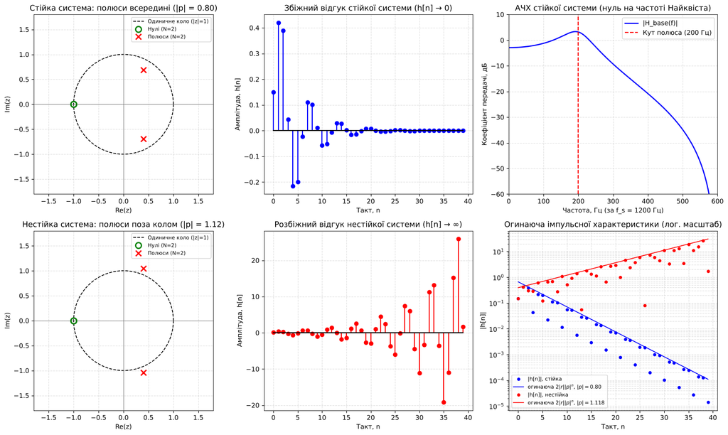

```python
n_imp = 40
n_arr = np.arange(n_imp)
delta = np.zeros(n_imp); delta[0] = 1.0
h_st = signal.lfilter(b_st, a_st, delta)
h_un = signal.lfilter(b_st, a_un, delta)

def impulse_by_residues(b, a, n):
    r, p, k = signal.residuez(b, a)                      # H(z) = sum r_i/(1 - p_i z^-1) + sum k_j z^-j
    h = np.array([np.sum(r * p ** m) for m in n], dtype=complex)
    for j, kj in enumerate(k):
        h[j] += kj
    env = np.array([np.sum(np.abs(r) * np.abs(p) ** m) for m in n])
    return h.real, env, r, p

h_st_res, env_st, r_st, _ = impulse_by_residues(b_st, a_st, n_arr)
h_un_res, env_un, r_un, _ = impulse_by_residues(b_st, a_un, n_arr)
assert np.allclose(h_st, h_st_res) and np.allclose(h_un, h_un_res)

print("h[n], n = 0..7 (стійка):  ", np.round(h_st[:8], 4))
print("h[n], n = 0..7 (нестійка):", np.round(h_un[:8], 4))
print(f"\nСтійка:   |h[39]| = {abs(h_st[-1]):.2e}; огинаюча 2|r||p|^n = {env_st[-1]:.2e}; sum|h[n]| (n<40) = {np.sum(np.abs(h_st)):.3f}")
print(f"Нестійка: max|h[n]| = {np.max(np.abs(h_un)):.2f}; |h[39]| = {abs(h_un[-1]):.2f}; огинаюча = {env_un[-1]:.2f}; sum|h[n]| (n<40) = {np.sum(np.abs(h_un)):.1f} (розбігається)")
print(f"Усталене значення стійкої системи: сума h[n] = {np.sum(h_st):.4f} (H(1) = {H1:.4f})")
assert abs(np.sum(h_st) - H1) < 1e-3 and np.all(np.abs(h_st) <= env_st + 1e-12)

fig, axes = plt.subplots(2, 3, figsize=(16, 9.5))
def plot_zplane(b, a, ax, title, pole_origin=0):
    """Діаграма нулів ('o') і полюсів ('x') з одиничним колом."""
    zz, pp, _ = signal.tf2zpk(b, a)
    th = np.linspace(0, 2 * np.pi, 400)
    ax.plot(np.cos(th), np.sin(th), 'k--', lw=1.2, label='Одиничне коло (|z|=1)')
    ax.axhline(0, color='gray', lw=0.8); ax.axvline(0, color='gray', lw=0.8)
    if len(zz):
        ax.plot(zz.real, zz.imag, 'go', ms=9, mew=2, fillstyle='none', label=f'Нулі (N={len(zz)})')
    if len(pp):
        ax.plot(pp.real, pp.imag, 'rx', ms=9, mew=2, label=f'Полюси (N={len(pp)})')
    if pole_origin:
        ax.plot([0], [0], 'rx', ms=9, mew=2, label=f'Полюс z=0 (кратність {pole_origin})')
    ax.set_title(title); ax.set_xlabel("Re(z)"); ax.set_ylabel("Im(z)")
    ax.set_xlim([-1.8, 1.8]); ax.set_ylim([-1.8, 1.8]); ax.set_aspect('equal'); ax.grid(True)
    ax.legend(loc='upper right', fontsize=8)
    return zz, pp

plot_zplane(b_st, a_st, axes[0, 0], f"Стійка система: полюси всередині (|p| = {abs(p_st[0]):.2f})")
axes[0, 1].stem(n_arr, h_st, linefmt='b-', markerfmt='bo', basefmt='k-')
axes[0, 1].set_title("Збіжний відгук стійкої системи (h[n] → 0)")
axes[0, 1].set_xlabel("Такт, n"); axes[0, 1].set_ylabel("Амплітуда, h[n]"); axes[0, 1].grid(True)

axes[0, 2].plot(f_h, 20 * np.log10(np.maximum(np.abs(H_st), 1e-6)), 'b-', lw=1.8, label='|H_base(f)|')
axes[0, 2].axvline(f_pole, color='r', ls='--', label=f'Кут полюса ({f_pole:.0f} Гц)')
axes[0, 2].set_title("АЧХ стійкої системи (нуль на частоті Найквіста)")
axes[0, 2].set_xlabel("Частота, Гц (за f_s = 1200 Гц)"); axes[0, 2].set_ylabel("Коефіцієнт передачі, дБ")
axes[0, 2].set_ylim([-60, 10]); axes[0, 2].set_xlim([0, fs / 2]); axes[0, 2].grid(True); axes[0, 2].legend()

plot_zplane(b_st, a_un, axes[1, 0], f"Нестійка система: полюси поза колом (|p| = {abs(p_un[0]):.2f})")
axes[1, 1].stem(n_arr, h_un, linefmt='r-', markerfmt='ro', basefmt='k-')
axes[1, 1].set_title("Розбіжний відгук нестійкої системи (h[n] → ∞)")
axes[1, 1].set_xlabel("Такт, n"); axes[1, 1].set_ylabel("Амплітуда, h[n]"); axes[1, 1].grid(True)

axes[1, 2].semilogy(n_arr, np.maximum(np.abs(h_st), 1e-12), 'bo', ms=4, label='|h[n]|, стійка')
axes[1, 2].semilogy(n_arr, env_st, 'b-', lw=1.2, label=r'огинаюча $2|r||p|^n$, $|p|=0.80$')
axes[1, 2].semilogy(n_arr, np.maximum(np.abs(h_un), 1e-12), 'ro', ms=4, label='|h[n]|, нестійка')
axes[1, 2].semilogy(n_arr, env_un, 'r-', lw=1.2, label=r'огинаюча $2|r||p|^n$, $|p|=1.118$')
axes[1, 2].set_title("Огинаюча імпульсної характеристики (лог. масштаб)")
axes[1, 2].set_xlabel("Такт, n"); axes[1, 2].set_ylabel("|h[n]|"); axes[1, 2].grid(True, which='both'); axes[1, 2].legend(fontsize=8)
plt.tight_layout()
plt.savefig("figures/zplane_stable_vs_unstable.png", dpi=200)
plt.show()
```

## 4. Синтез цифрових фільтрів ФВЧ: КІХ (`firwin`) та НІХ (`butter`)

Розраховуються АЧХ, ФЧХ та груповий час затримки через `signal.freqz` та `signal.group_delay`. Додатково перевіряються: симетрія імпульсної характеристики КІХ (лінійна фаза), аналітична формула АЧХ Баттерворта з попереднім викривленням частоти, розташування полюсів.

```
======================================================================================
ПАРАМЕТРИ СИНТЕЗОВАНИХ ФІЛЬТРІВ ФВЧ (fs = 1200 Гц, fc = 350 Гц)
======================================================================================
КІХ: 51 коефіцієнтів, порядок 50, симетрична h[n]; групова затримка 25 відліків = 20.83 мс; полюси: 50 у z = 0
НІХ: b = [ 0.05299 -0.21195  0.31792 -0.21195  0.05299]
     a = [1.      0.65147 0.62047 0.14738 0.02617]
     |p| = [0.2385 0.2385 0.6784 0.6784] -> стійкий: True

                                     КІХ (Hamming)   НІХ (Butterworth)
Підсилення на f1 = 100 Гц, дБ               -61.89              -54.96
Підсилення на 250 Гц, дБ                    -61.73              -18.47
Підсилення на fc = 350 Гц, дБ                -6.02               -3.01
Підсилення на f2 = 450 Гц, дБ                -0.01               -0.03
Макс. підсилення в 0-250 Гц, дБ             -55.37              -18.48
Нерівномірність у 400-600 Гц, дБ             0.031               0.421
ГЧЗ на f2 = 450 Гц, відліків                 25.00                2.34
ГЧЗ у смузі 400-600 Гц (мін...макс)   25.00...25.00          1.70...3.18
ГЧЗ у смузі 300-400 Гц (мін...макс)   25.00...25.00          2.85...3.84
======================================================================================
Формула АЧХ Баттерворта збігається з freqz: max|Δ| = 1.0e-15
Відхилення ГЧЗ КІХ від 25 відліків: max|Δ| = 1.2e-08
```

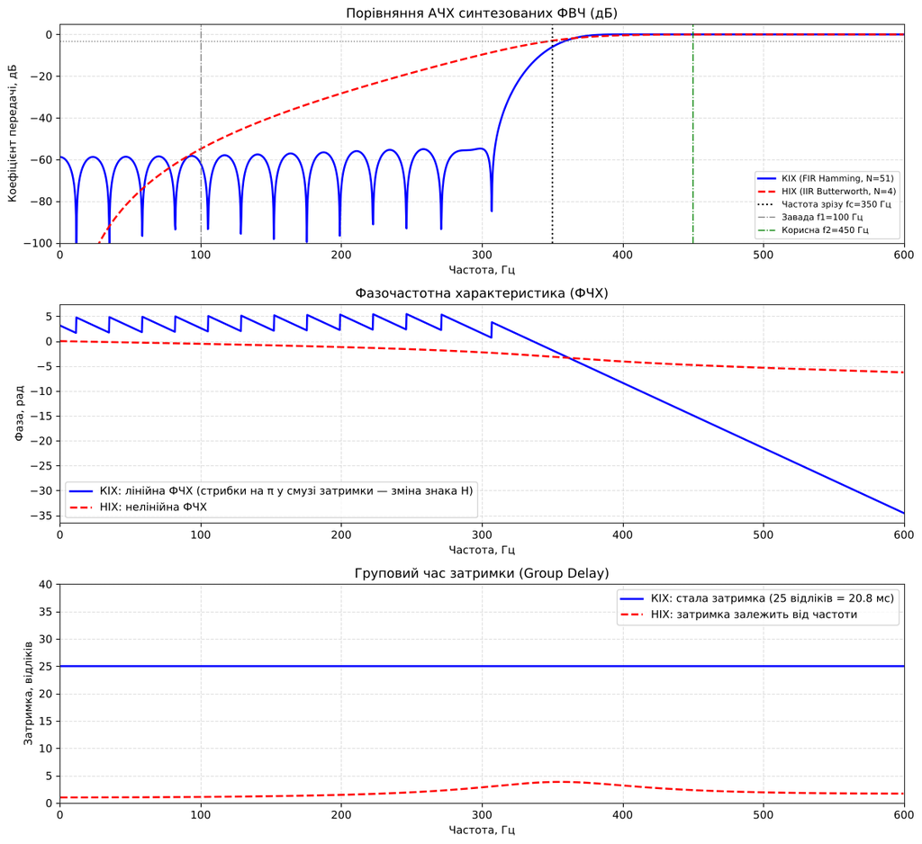

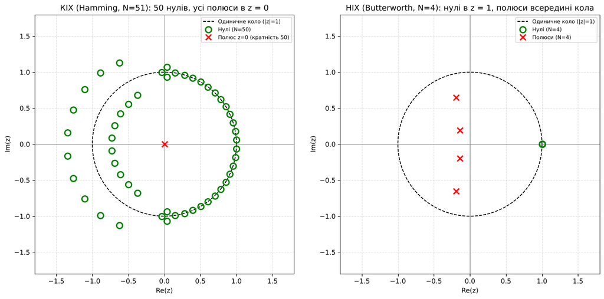

```python
# 1) КІХ-фільтр ФВЧ методом вікна Хеммінга, 51 відлік (непарна довжина, тип I)
fir = signal.firwin(N_fir, f_c, fs=fs, window='hamming', pass_zero='highpass')
# 2) НІХ-фільтр Баттерворта 4-го порядку, білінійне перетворення
b_iir, a_iir = signal.butter(N_iir, f_c, btype='highpass', fs=fs)

f_grid, H_fir = signal.freqz(fir, 1.0, worN=2048, fs=fs)
_, H_iir = signal.freqz(b_iir, a_iir, worN=2048, fs=fs)
with warnings.catch_warnings():
    warnings.simplefilter("ignore")                    # на f = 0 для ФВЧ H(0) = 0, ГЧЗ не визначена
    _, gd_fir = signal.group_delay((fir, 1.0), w=f_grid, fs=fs)
    _, gd_iir = signal.group_delay((b_iir, a_iir), w=f_grid, fs=fs)
gd_fir[0] = np.nan; gd_iir[0] = np.nan
db = lambda H: 20 * np.log10(np.maximum(np.abs(H), 1e-6))

def gain_db_at(b, a, f):
    _, H = signal.freqz(b, a, worN=np.atleast_1d(np.asarray(f, dtype=float)), fs=fs)
    return 20 * np.log10(np.abs(H))

# --- Перевірки
assert np.allclose(fir, fir[::-1])                                   # симетрія -> лінійна ФЧХ
tau_fir = (N_fir - 1) / 2
H_formula = 1 / np.sqrt(1 + (np.tan(np.pi * f_c / fs) / np.tan(np.pi * f_grid[1:] / fs)) ** (2 * N_iir))
assert np.allclose(np.abs(H_iir[1:]), H_formula)                     # білінійне перетворення з викривленням частоти
p_iir = np.roots(a_iir); z_iir = np.roots(b_iir)
p_fir_origin = N_fir - 1                                             # КІХ: 50 полюсів у z = 0

pass_band = f_grid >= 400
stop_band = f_grid <= 250
print("=" * 86)
print("ПАРАМЕТРИ СИНТЕЗОВАНИХ ФІЛЬТРІВ ФВЧ (fs = 1200 Гц, fc = 350 Гц)")
print("=" * 86)
print(f"КІХ: {N_fir} коефіцієнтів, порядок {N_fir - 1}, симетрична h[n]; групова затримка {tau_fir:.0f} відліків = {tau_fir / fs * 1e3:.2f} мс; полюси: {p_fir_origin} у z = 0")
print(f"НІХ: b = {np.round(b_iir, 5)}\n     a = {np.round(a_iir, 5)}")
print(f"     |p| = {np.round(np.sort(np.abs(p_iir)), 4)} -> стійкий: {bool(np.all(np.abs(p_iir) < 1))}")
print(f"\n{'':<34}{'КІХ (Hamming)':>16}{'НІХ (Butterworth)':>20}")
for lab, f in [("Підсилення на f1 = 100 Гц, дБ", f1), ("Підсилення на 250 Гц, дБ", 250.0),
               ("Підсилення на fc = 350 Гц, дБ", f_c), ("Підсилення на f2 = 450 Гц, дБ", f2)]:
    print(f"{lab:<34}{gain_db_at(fir, 1.0, f)[0]:16.2f}{gain_db_at(b_iir, a_iir, f)[0]:20.2f}")
print(f"{'Макс. підсилення в 0-250 Гц, дБ':<34}{db(H_fir)[stop_band].max():16.2f}{db(H_iir)[stop_band].max():20.2f}")
print(f"{'Нерівномірність у 400-600 Гц, дБ':<34}{np.ptp(db(H_fir)[pass_band]):16.3f}{np.ptp(db(H_iir)[pass_band]):20.3f}")
print(f"{'ГЧЗ на f2 = 450 Гц, відліків':<34}{np.interp(f2, f_grid, gd_fir):16.2f}{np.interp(f2, f_grid, gd_iir):20.2f}")
print(f"{'ГЧЗ у смузі 400-600 Гц (мін...макс)':<34}{gd_fir[pass_band].min():8.2f}...{gd_fir[pass_band].max():<7.2f}{gd_iir[pass_band].min():12.2f}...{gd_iir[pass_band].max():<7.2f}")
print(f"{'ГЧЗ у смузі 300-400 Гц (мін...макс)':<34}{gd_fir[(f_grid >= 300) & (f_grid <= 400)].min():8.2f}...{gd_fir[(f_grid >= 300) & (f_grid <= 400)].max():<7.2f}{gd_iir[(f_grid >= 300) & (f_grid <= 400)].min():12.2f}...{gd_iir[(f_grid >= 300) & (f_grid <= 400)].max():<7.2f}")
print("=" * 86)
print(f"Формула АЧХ Баттерворта збігається з freqz: max|Δ| = {np.max(np.abs(np.abs(H_iir[1:]) - H_formula)):.1e}")
print(f"Відхилення ГЧЗ КІХ від {tau_fir:.0f} відліків: max|Δ| = {np.nanmax(np.abs(gd_fir - tau_fir)):.1e}")

fig, axes = plt.subplots(3, 1, figsize=(12, 11))
ax = axes[0]
ax.plot(f_grid, db(H_fir), 'b-', lw=1.8, label=f'КІХ (FIR Hamming, N={N_fir})')
ax.plot(f_grid, db(H_iir), 'r--', lw=1.8, label=f'НІХ (IIR Butterworth, N={N_iir})')
ax.axvline(f_c, color='k', ls=':', label=f'Частота зрізу fc={f_c:.0f} Гц')
ax.axvline(f1, color='gray', ls='-.', lw=1, label=f'Завада f1={f1:.0f} Гц')
ax.axvline(f2, color='g', ls='-.', lw=1, label=f'Корисна f2={f2:.0f} Гц')
ax.axhline(-3, color='gray', ls=':', lw=1)
ax.set_title("Порівняння АЧХ синтезованих ФВЧ (дБ)")
ax.set_xlabel("Частота, Гц"); ax.set_ylabel("Коефіцієнт передачі, дБ")
ax.set_xlim([0, fs / 2]); ax.set_ylim([-100, 5]); ax.grid(True); ax.legend(loc='lower right', fontsize=8)

ax = axes[1]
ax.plot(f_grid, np.unwrap(np.angle(H_fir)), 'b-', lw=1.8, label='КІХ: лінійна ФЧХ (стрибки на π у смузі затримки — зміна знака H)')
ax.plot(f_grid, np.unwrap(np.angle(H_iir)), 'r--', lw=1.8, label='НІХ: нелінійна ФЧХ')
ax.set_title("Фазочастотна характеристика (ФЧХ)")
ax.set_xlabel("Частота, Гц"); ax.set_ylabel("Фаза, рад"); ax.set_xlim([0, fs / 2]); ax.grid(True); ax.legend()

ax = axes[2]
ax.plot(f_grid, gd_fir, 'b-', lw=1.8, label=f'КІХ: стала затримка ({tau_fir:.0f} відліків = {tau_fir / fs * 1e3:.1f} мс)')
ax.plot(f_grid, gd_iir, 'r--', lw=1.8, label='НІХ: затримка залежить від частоти')
ax.set_title("Груповий час затримки (Group Delay)")
ax.set_xlabel("Частота, Гц"); ax.set_ylabel("Затримка, відліків")
ax.set_xlim([0, fs / 2]); ax.set_ylim([0, 40]); ax.grid(True); ax.legend()
plt.tight_layout()
plt.savefig("figures/filter_frequency_responses.png", dpi=200)
plt.show()

fig, axes = plt.subplots(1, 2, figsize=(13, 6.2))
plot_zplane(fir, [1.0], axes[0], f"КІХ (Hamming, N={N_fir}): 50 нулів, усі полюси в z = 0", pole_origin=p_fir_origin)
plot_zplane(b_iir, a_iir, axes[1], f"НІХ (Butterworth, N={N_iir}): нулі в z = 1, полюси всередині кола")
plt.tight_layout()
plt.savefig("figures/designed_filters_zplane.png", dpi=200)
plt.show()
```

## 5. Фільтрація зашумленого сигналу та спектральний аналіз

```
==================================================================================
ОЦІНКА РЕЗУЛЬТАТІВ ФІЛЬТРАЦІЇ (усталений фрагмент, n = 60...539, Δf = 2.5 Гц)
==================================================================================
                                                Вхід         КІХ         НІХ
Амплітуда в біні f1 = 100 Гц (із шумом), В    1.9905     0.00135     0.00356
Амплітуда в біні f2 = 450 Гц (із шумом), В    1.5317      1.5232      1.5269
Придушення f1 (чиста складова), дБ                        -61.89      -54.96
Теоретичне підсилення |H(f1)|, дБ                         -61.89      -54.96
Збереження амплітуди f2 (чиста), %                         99.91       99.64
Теоретично 100·|H(f2)|, %                                  99.91       99.64
Потужність шуму: виміряна, В²                 0.0909      0.0334      0.0348
Потужність шуму: σ²·Σh², В²                   0.0900      0.0361      0.0377
Залишок завади f1 (потужність), В²            2.0000    1.30e-06    6.39e-06
SNR (корисна проти завади+шуму), дБ            -2.65       15.26       15.06
Виграш у SNR, дБ                                           17.92       17.72
==================================================================================
```

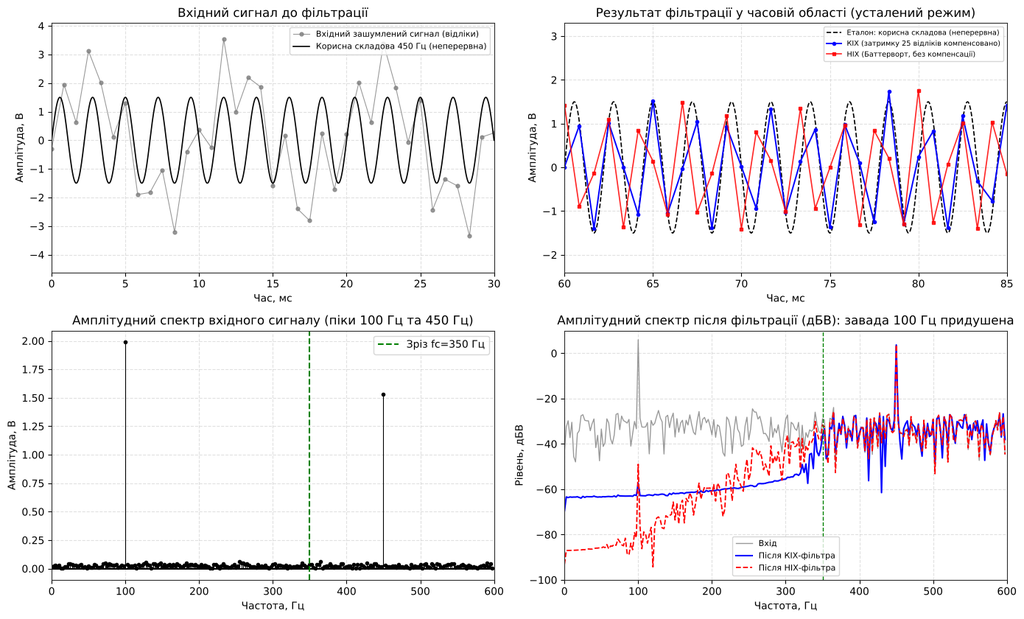

```python
T_total = 0.5
t_sig = np.arange(0, T_total, 1.0 / fs)
N_total = len(t_sig)                                   # 600 відліків

rng = np.random.default_rng(123)
s_f1 = A1 * np.sin(2 * np.pi * f1 * t_sig)             # завада (смуга затримки)
s_f2 = A2 * np.sin(2 * np.pi * f2 * t_sig)             # корисна складова (смуга пропускання)
s_noise = rng.normal(0.0, sigma, N_total)
s_input = s_f1 + s_f2 + s_noise

y_fir = signal.lfilter(fir, 1.0, s_input)
y_iir = signal.lfilter(b_iir, a_iir, s_input)
delay = (N_fir - 1) // 2
y_fir_aligned = y_fir[delay:]                          # компенсація затримки КІХ без циклічного зсуву
t_aligned = t_sig[:N_total - delay]

seg = slice(60, 540)                                   # усталений фрагмент, 480 відліків (кратно 24)
N_seg = seg.stop - seg.start
df_seg = fs / N_seg
k1, k2 = int(round(f1 / df_seg)), int(round(f2 / df_seg))
assert np.isclose(k1 * df_seg, f1) and np.isclose(k2 * df_seg, f2)    # гармоніки точно в бінах

def amp_spectrum(x):
    X = np.fft.fft(x[seg])
    a = 2.0 / N_seg * np.abs(X[:N_seg // 2])
    a[0] /= 2.0
    return a
f_axis = np.arange(N_seg // 2) * df_seg
mag_in, mag_fir, mag_iir = amp_spectrum(s_input), amp_spectrum(y_fir), amp_spectrum(y_iir)

# --- Амплітуди та теоретичні підсилення
g_fir = {f: gain_db_at(fir, 1.0, f)[0] for f in (f1, f2)}
g_iir = {f: gain_db_at(b_iir, a_iir, f)[0] for f in (f1, f2)}
# Придушення f1 і збереження f2 визначаються на чистих складових (фільтри лінійні): у зашумленому виході
# рівень у біні f1 (~1 мВ) обмежений витоком шуму смуги пропускання, а не залишком самої гармоніки.
ampc = lambda b, a, x, k: amp_spectrum(signal.lfilter(b, a, x))[k]
att_fir_f1 = 20 * np.log10(ampc(fir, 1.0, s_f1, k1) / A1);          att_iir_f1 = 20 * np.log10(ampc(b_iir, a_iir, s_f1, k1) / A1)
keep_fir_f2 = 100 * ampc(fir, 1.0, s_f2, k2) / A2;                  keep_iir_f2 = 100 * ampc(b_iir, a_iir, s_f2, k2) / A2

# --- SNR на усталому фрагменті (корисна складова проти завади + шуму)
P = lambda x: float(np.mean(x[seg] ** 2))
resid_in = s_f1 + s_noise
snr_in = 10 * np.log10(P(s_f2) / P(resid_in))
out = {}
for name, (b, a) in {"КІХ": (fir, [1.0]), "НІХ": (b_iir, a_iir)}.items():
    useful = signal.lfilter(b, a, s_f2); resid = signal.lfilter(b, a, resid_in)
    out[name] = dict(snr=10 * np.log10(P(useful) / P(resid)), noise_out=P(signal.lfilter(b, a, s_noise)), resid_f1=P(signal.lfilter(b, a, s_f1)))
snr_fir, snr_iir = out["КІХ"]["snr"], out["НІХ"]["snr"]

# Теоретична потужність шуму на виході: sigma^2 * sum h^2
h_iir_long = signal.lfilter(b_iir, a_iir, np.r_[1.0, np.zeros(4095)])
noise_gain_fir, noise_gain_iir = float(np.sum(fir ** 2)), float(np.sum(h_iir_long ** 2))
print("=" * 82)
print("ОЦІНКА РЕЗУЛЬТАТІВ ФІЛЬТРАЦІЇ (усталений фрагмент, n = 60...539, Δf = 2.5 Гц)")
print("=" * 82)
print(f"{'':<42}{'Вхід':>10}{'КІХ':>12}{'НІХ':>12}")
print(f"{'Амплітуда в біні f1 = 100 Гц (із шумом), В':<42}{mag_in[k1]:10.4f}{mag_fir[k1]:12.5f}{mag_iir[k1]:12.5f}")
print(f"{'Амплітуда в біні f2 = 450 Гц (із шумом), В':<42}{mag_in[k2]:10.4f}{mag_fir[k2]:12.4f}{mag_iir[k2]:12.4f}")
print(f"{'Придушення f1 (чиста складова), дБ':<42}{'':>10}{att_fir_f1:12.2f}{att_iir_f1:12.2f}")
print(f"{'Теоретичне підсилення |H(f1)|, дБ':<42}{'':>10}{g_fir[f1]:12.2f}{g_iir[f1]:12.2f}")
print(f"{'Збереження амплітуди f2 (чиста), %':<42}{'':>10}{keep_fir_f2:12.2f}{keep_iir_f2:12.2f}")
print(f"{'Теоретично 100·|H(f2)|, %':<42}{'':>10}{100 * 10 ** (g_fir[f2] / 20):12.2f}{100 * 10 ** (g_iir[f2] / 20):12.2f}")
print(f"{'Потужність шуму: виміряна, В²':<42}{P(s_noise):10.4f}{out['КІХ']['noise_out']:12.4f}{out['НІХ']['noise_out']:12.4f}")
print(f"{'Потужність шуму: σ²·Σh², В²':<42}{sigma ** 2:10.4f}{sigma ** 2 * noise_gain_fir:12.4f}{sigma ** 2 * noise_gain_iir:12.4f}")
print(f"{'Залишок завади f1 (потужність), В²':<42}{P(s_f1):10.4f}{out['КІХ']['resid_f1']:12.2e}{out['НІХ']['resid_f1']:12.2e}")
print(f"{'SNR (корисна проти завади+шуму), дБ':<42}{snr_in:10.2f}{snr_fir:12.2f}{snr_iir:12.2f}")
print(f"{'Виграш у SNR, дБ':<42}{'':>10}{snr_fir - snr_in:12.2f}{snr_iir - snr_in:12.2f}")
print("=" * 82)
assert abs(att_fir_f1 - g_fir[f1]) < 0.05 and abs(att_iir_f1 - g_iir[f1]) < 0.05
assert abs(keep_fir_f2 - 100 * 10 ** (g_fir[f2] / 20)) < 0.05 and abs(keep_iir_f2 - 100 * 10 ** (g_iir[f2] / 20)) < 0.05

fig, axes = plt.subplots(2, 2, figsize=(14, 8.5))
ax = axes[0, 0]
t_fine = np.linspace(0, T_total, 60000)                # неперервна еталонна крива (450 Гц дає лише 2.67 відліку на період)
ref_fine = A2 * np.sin(2 * np.pi * f2 * t_fine)
ax.plot(t_sig * 1e3, s_input, color='gray', alpha=0.8, marker='o', ms=3.5, lw=0.8, label='Вхідний зашумлений сигнал (відліки)')
ax.plot(t_fine * 1e3, ref_fine, 'k-', lw=1.2, label='Корисна складова 450 Гц (неперервна)')
ax.set_title("Вхідний сигнал до фільтрації")
ax.set_xlabel("Час, мс"); ax.set_ylabel("Амплітуда, В"); ax.set_xlim([0, 30]); ax.grid(True); ax.legend(loc='upper right', fontsize=8)

ax = axes[0, 1]
ax.plot(t_fine * 1e3, ref_fine, 'k--', lw=1.2, label='Еталон: корисна складова (неперервна)')
ax.plot(t_aligned * 1e3, y_fir_aligned, 'b-o', ms=3, lw=1.4, label='КІХ (затримку 25 відліків компенсовано)')
ax.plot(t_sig * 1e3, y_iir, 'r-s', ms=3, lw=1.2, alpha=0.85, label='НІХ (Баттерворт, без компенсації)')
ax.set_title("Результат фільтрації у часовій області (усталений режим)")
ax.set_xlabel("Час, мс"); ax.set_ylabel("Амплітуда, В"); ax.set_xlim([60, 85]); ax.set_ylim([-2.4, 3.3]); ax.grid(True); ax.legend(loc='upper right', fontsize=7)

ax = axes[1, 0]
ml, sl, bl = ax.stem(f_axis, mag_in, linefmt='k-', markerfmt='ko', basefmt='k-')
plt.setp(ml, markersize=3); plt.setp(sl, linewidth=0.8)
ax.axvline(f_c, color='g', ls='--', label=f'Зріз fc={f_c:.0f} Гц')
ax.set_title("Амплітудний спектр вхідного сигналу (піки 100 Гц та 450 Гц)")
ax.set_xlabel("Частота, Гц"); ax.set_ylabel("Амплітуда, В"); ax.set_xlim([0, fs / 2]); ax.grid(True); ax.legend()

ax = axes[1, 1]
dbv = lambda a: 20 * np.log10(np.maximum(a, 1e-7))
ax.plot(f_axis, dbv(mag_in), color='gray', lw=1.0, alpha=0.8, label='Вхід')
ax.plot(f_axis, dbv(mag_fir), 'b-', lw=1.5, label='Після КІХ-фільтра')
ax.plot(f_axis, dbv(mag_iir), 'r--', lw=1.3, label='Після НІХ-фільтра')
ax.axvline(f_c, color='g', ls='--', lw=1)
ax.set_title("Амплітудний спектр після фільтрації (дБВ): завада 100 Гц придушена")
ax.set_xlabel("Частота, Гц"); ax.set_ylabel("Рівень, дБВ"); ax.set_xlim([0, fs / 2]); ax.set_ylim([-100, 10]); ax.grid(True); ax.legend(loc='lower center', fontsize=8)
plt.tight_layout()
plt.savefig("figures/signal_filtering_results.png", dpi=200)
plt.show()
```

## 6. Експорт результатів

```python
np.savetxt("data/frequency_responses.csv",
           np.column_stack([f_grid, db(H_fir), db(H_iir), np.unwrap(np.angle(H_fir)), np.unwrap(np.angle(H_iir)), gd_fir, gd_iir]),
           delimiter=",", header="f_Hz,gain_fir_dB,gain_iir_dB,phase_fir_rad,phase_iir_rad,gd_fir_samples,gd_iir_samples", comments="")
np.savetxt("data/filtered_signals.csv",
           np.column_stack([np.arange(N_total), t_sig, s_input, s_f2, y_fir, y_iir]),
           delimiter=",", header="n,t_s,input,useful_450Hz,fir_filtered,iir_filtered", comments="")
np.savetxt("data/fir_coefficients.csv", np.column_stack([np.arange(N_fir), fir]), delimiter=",", header="n,h_fir", comments="")

results = dict(
    variant=2, fs=fs, fc=f_c, N_fir=N_fir, N_iir=N_iir,
    base_system=dict(b=b_st.tolist(), a_stable=a_st.tolist(), a_unstable=a_un.tolist(),
                     poles_stable=[[float(p.real), float(p.imag)] for p in p_st], modulus_stable=float(abs(p_st[0])),
                     poles_unstable=[[float(p.real), float(p.imag)] for p in p_un], modulus_unstable=float(abs(p_un[0])),
                     stable=stable_st, unstable_is_stable=stable_un, H1=float(H1), f_peak_hz=f_peak, f_pole_hz=f_pole),
    iir=dict(b=b_iir.tolist(), a=a_iir.tolist(), pole_moduli=np.abs(p_iir).tolist()),
    fir=dict(taps=fir.tolist(), group_delay_samples=float(tau_fir), group_delay_ms=float(tau_fir / fs * 1e3)),
    gains_db=dict(fir={str(int(f)): float(gain_db_at(fir, 1.0, f)[0]) for f in (f1, 250, f_c, f2)},
                  iir={str(int(f)): float(gain_db_at(b_iir, a_iir, f)[0]) for f in (f1, 250, f_c, f2)}),
    filtering=dict(amp_in_f1=float(mag_in[k1]), amp_in_f2=float(mag_in[k2]),
                   amp_fir_f1=float(mag_fir[k1]), amp_fir_f2=float(mag_fir[k2]),
                   amp_iir_f1=float(mag_iir[k1]), amp_iir_f2=float(mag_iir[k2]),
                   attenuation_fir_f1_db=float(att_fir_f1), attenuation_iir_f1_db=float(att_iir_f1),
                   keep_fir_f2_pct=float(keep_fir_f2), keep_iir_f2_pct=float(keep_iir_f2),
                   snr_in_db=float(snr_in), snr_fir_db=float(snr_fir), snr_iir_db=float(snr_iir),
                   noise_gain_fir=noise_gain_fir, noise_gain_iir=noise_gain_iir),
)
with open("data/results.json", "w", encoding="utf-8") as f:
    json.dump(results, f, ensure_ascii=False, indent=1)
print("Готово: figures/, data/")
```

```
Готово: figures/, data/
```

## Висновки

1. **Стійкість у z-площині.** Базова функція $H_{base}(z)=\dfrac{0.15(1+z^{-1})^2}{1-0.8z^{-1}+0.64z^{-2}}$ має подвійний нуль $z=-1$ та полюси $p_{1,2}=0.4\pm j0.6928$ з модулем $|p|=0.8<1$, тобто стійка; координати збігаються з аналітичним розрахунком. Нуль на частоті Найквіста обнуляє АЧХ при $f=f_s/2$, а полюс із кутом $60^\circ$ формує резонансний пік ($|H|_{max}=1.47$ на $191.6$ Гц при куті полюса, що відповідає $200$ Гц). Імпульсна характеристика затухає ($|h[39]|\approx1.4\cdot10^{-5}$, $\sum_{n<40}|h[n]|=1.90$), $\sum h[n]=0.714=H(1)$ і лежить під огинаючою $2|r||p|^n$. Збільшення $a_2$ до $1.25$ виводить полюси ($0.4\pm j1.044$, $|p|=1.118$) за одиничне коло: відгук необмежено зростає ($\max|h|=25.9$ на 40 тактах, $\sum|h|=171$) уздовж огинаючої $1.118^n$, що підтверджує розклад на лишки.
2. **КІХ-фільтр ФВЧ** (вікно Хеммінга, 51 відлік, $f_c=350$ Гц). Імпульсна характеристика симетрична, тому ФЧХ строго лінійна, а групова затримка стала й дорівнює 25 відлікам ($20.83$ мс; відхилення $\sim10^{-8}$). Усі 50 полюсів лежать у $z=0$, фільтр безумовно стійкий. Для ФВЧ потрібна непарна довжина (тип I), інакше нуль на частоті Найквіста унеможливлює пропускання. Підсилення на $f_c$ становить $-6.02$ дБ (метод вікна задає зріз за рівнем $0.5$), у смузі затримки не вище $-55.4$ дБ (на $f_1=100$ Гц $-61.9$ дБ), нерівномірність у смузі пропускання $400\ldots600$ Гц лише $0.03$ дБ.
3. **НІХ-фільтр Баттерворта 4-го порядку.** Усього 9 коефіцієнтів (5 у чисельнику та 4 у зворотному зв'язку) замість 51; полюси мають модулі $0.2385$ (×2) та $0.6784$ (×2), тобто з істотним запасом стійкості. Білінійне перетворення з викривленням частоти дає $-3.01$ дБ на $f_c$, а чисельна АЧХ збігається з формулою $[1+(\tan\frac{\Omega_c}{2}/\tan\frac{\Omega}{2})^{8}]^{-1/2}$ з точністю $10^{-15}$. Спад АЧХ значно пологіший: $-55.0$ дБ на $100$ Гц, але лише $-18.5$ дБ на $250$ Гц (у КІХ $-61.7$ дБ). У смузі пропускання АЧХ монотонна (спад $0.42$ дБ у $400\ldots600$ Гц). ФЧХ нелінійна, групова затримка змінюється від $1.7$ до $3.2$ відліку у смузі $400\ldots600$ Гц з піком $\approx3.8$ відліку поблизу зрізу, зате затримка на $450$ Гц ($2.3$ відліку $\approx1.9$ мс) приблизно в 11 разів менша, ніж у КІХ ($20.8$ мс).
4. **Фільтрація сигналу** ($f_1=100$ Гц завада, $f_2=450$ Гц корисна, $\sigma=0.30$ В), усталений фрагмент $n=60\ldots539$ без витоку спектра. Придушення $f_1$: $-61.89$ дБ (КІХ) та $-54.96$ дБ (НІХ), що збігається з теоретичним $|H(f_1)|$; залишок потужності завади $1.3\cdot10^{-6}$ та $6.4\cdot10^{-6}$ В² проти $2.0$ В² на вході. Амплітуда корисної гармоніки зберігається на $99.91\ \%$ та $99.64\ \%$ (збігається з $|H(f_2)|$). У зашумленому виході рівень у біні $f_1$ складає $1.35$ мВ (КІХ) та $3.56$ мВ (НІХ): для НІХ це залишок самої гармоніки ($2.0\cdot10^{-54.96/20}=3.55$ мВ), для КІХ він визначається витоком спектра шуму смуги пропускання. Потужність шуму на виході ($0.033$ та $0.035$ В²) відповідає $\sigma^2\sum h^2$ ($0.036$ та $0.038$ В²) у межах статистичного розкиду, тобто шум зменшується приблизно в 2.5–2.7 раза, оскільки лише його частина в смузі пропускання досягає виходу. SNR зростає з $-2.65$ дБ до $15.26$ дБ (КІХ) та $15.06$ дБ (НІХ), виграш $17.9$ та $17.7$ дБ; вихідний SNR обмежений вже не завадою, а шумом у смузі пропускання.
5. **Порівняння та вибір.** За здатністю придушити саму заваду $f_1$ обидва фільтри близькі ($-62$ та $-55$ дБ), тож для цього сигналу НІХ 4-го порядку цілком достатній і вимагає 9 множень на відлік проти 51. Натомість КІХ гарантує строго лінійну фазу (форма сигналу не спотворюється), безумовну стійкість та значно глибше придушення в усій смузі затримки ($\le-55$ дБ проти $-18$ дБ на 250 Гц), але ціною затримки 25 відліків (компенсується зсувом $y[n+25]$ при офлайн-обробці) та вищих обчислювальних витрат. Для вимірювальних і біомедичних сигналів, де важлива форма, обирають КІХ; для задач із жорсткими вимогами до затримки та ресурсів, коли нелінійність фази допустима, — НІХ, контролюючи, що $|p_k|<1$.

## Контрольні питання:

### 1. Що таке передавальна функція $H(z)$ дискретної системи, і як вона пов'язана з коефіцієнтами лінійного різницевого рівняння?

**Передавальна функція $H(z)$** лінійної стаціонарної дискретної системи (ЛСДС) — це відношення $z$-перетворення вихідного сигналу $Y(z)$ до $z$-перетворення вхідного сигналу $X(z)$ за нульових початкових умов, або еквівалентно — двостороннє $z$-перетворення її імпульсної характеристики $h[n]$:

$$H(z) = \frac{Y(z)}{X(z)} = \sum_{n=-\infty}^{\infty} h[n]z^{-n}$$

**Зв'язок із коефіцієнтами лінійного різницевого рівняння:** Робота ЛСДС описується лінійним різницевим рівнянням зі сталими коефіцієнтами:

$$\sum_{k=0}^{N} a_k y[n-k] = \sum_{m=0}^{M} b_m x[n-m]$$

Застосувавши $z$-перетворення до обох частин рівняння (за властивістю затримки $x[n-k] \leftrightarrow z^{-k}X(z)$ при нульових початкових умовах), отримуємо $H(z)$ у вигляді раціонального дробу:

$$H(z) = \frac{Y(z)}{X(z)} = \frac{\sum_{m=0}^{M} b_m z^{-m}}{\sum_{k=0}^{N} a_k z^{-k}} = \frac{b_0 + b_1 z^{-1} + \dots + b_M z^{-M}}{a_0 + a_1 z^{-1} + \dots + a_N z^{-N}}$$

- Коефіцієнти $b_m$ (при відліках вхідного сигналу — прямі зв'язки) формують **чисельник** $H(z)$ і визначають **нулі** системи.
- Коефіцієнти $a_k$ (при затриманих відліках вихідного сигналу — зворотні зв'язки, зазвичай нормовані до $a_0 = 1$) формують **знаменник** $H(z)$ і визначають **полюси** системи.

### 2. У чому полягає геометричний та алгебраїчний зміст критерію стійкості BIBO для лінійних стаціонарних дискретних систем у z-площині?

Система є **BIBO-стійкою** (*Bounded-Input, Bounded-Output*), якщо будь-який обмежений за амплітудою вхідний сигнал ($\vert{}x[n]\vert{} \le M_x < \infty$) викликає обмежений вихідний сигнал ($\vert{}y[n]\vert{} \le M_y < \infty$).

- **Алгебраїчний зміст:**
- У часовій області імпульсна характеристика системи має бути абсолютно сумованою:

$$\sum_{n=-\infty}^{\infty} \vert{}h[n]\vert{} < \infty$$

- У $z$-області область збіжності (ROC) передавальної функції $H(z)$ повинна містити одиничне коло $\vert{}z\vert{} = 1$. Для каузальної системи з раціональною $H(z)$ це означає, що модулі всіх її полюсів $p_k$ (коренів знаменника) мають бути строго меншими за одиницю:

$$\vert{}p_k\vert{} < 1 \quad \forall k = 1, 2, \dots, N$$

- **Геометричний зміст:** На комплексній $z$-площині всі полюси передавальної функції каузальної системи повинні розташовуватися **строго всередині одиничного кола** радіуса $R = 1$ із центром у початку координат ($\vert{}z\vert{} < 1$). Якщо хоча б один полюс лежить зовні кола ($\vert{}p_k\vert{} > 1$), система нестійка; якщо на самому колі ($\vert{}p_k\vert{} = 1$) — система перебуває на межі стійкості (не є BIBO-стійкою).

### 3. Як впливає розташування нулів та полюсів передавальної функції відносно одиничного кола на форму амплітудно-частотної характеристики (АЧХ)?

АЧХ $\vert{}H(e^{j\omega})\vert{}$ — це модуль передавальної функції, обчислений на одиничному колі $z = e^{j\omega}$ при зміні нормованої частоти $\omega \in [0, \pi]$. Геометрично значення АЧХ на частоті $\omega$ визначається відношенням добутку відстаней від точки $e^{j\omega}$ до всіх нулів $z_m$ до добутку відстаней від $e^{j\omega}$ до всіх полюсів $p_k$:

$$\vert{}H(e^{j\omega})\vert{} = \vert{}G\vert{} \frac{\prod_{m=1}^{M} \vert{}e^{j\omega} - z_m\vert{}}{\prod_{k=1}^{N} \vert{}e^{j\omega} - p_k\vert{}}$$

- **Вплив полюсів ($p_k$):** Оскільки відстані до полюсів знаходяться у **знаменнику**, наближення точки $e^{j\omega}$ до полюса зменшує знаменник і створює **підйом (резонансний пік)** на АЧХ поблизу частоти $\omega \approx \arg(p_k)$. Чим ближче полюс до одиничного кола ($\vert{}p_k\vert{} \to 1$), тим вищим і вужчим є пік.
- **Вплив нулів ($z_m$):** Оскільки відстані до нулів знаходяться у **чисельнику**, наближення точки $e^{j\omega}$ до нуля зменшує чисельник і створює **провал (ослаблення)** на АЧХ поблизу частоти $\omega \approx \arg(z_m)$. Якщо нуль лежить безпосередньо **на одиничному колі** ($\vert{}z_m\vert{} = 1$, $z_m = e^{j\omega_0}$), на цій частоті виникає повне придушення сигналу ($\vert{}H(e^{j\omega_0})\vert{} = 0$).
- **Нулі та полюси в початку координат ($z = 0$):** Вони рівновіддалені від усіх точок одиничного кола ($\vert{}e^{j\omega} - 0\vert{} = 1$), тому **не змінюють форму АЧХ**, а впливають лише на ФЧХ.

### 4. Чому всі цифрові КІХ-фільтри є безумовно стійкими, і за якої умови вони забезпечують строго лінійну фазочастотну характеристику?

- **Причина безумовної стійкості:** КІХ-фільтр (фільтр зі скінченною імпульсною характеристикою) не має зворотних зв'язків ($a_k = 0$ при $k \ge 1$), а його імпульсна характеристика $h[n]$ має скінченну довжину $L$. Сума модулів скінченної кількості скінченних відліків завжди скінченна ($\sum_{n=0}^{L-1} \vert{}h[n]\vert{} < \infty$). Геометрично у $z$-площині всі полюси КІХ-фільтра зосереджені лише в початку координат ($z = 0$), тобто строго всередині одиничного кола, що гарантує BIBO-стійкість за будь-яких коефіцієнтів фільтра.
- **Умова строго лінійної ФЧХ:** КІХ-фільтр довжиною $L$ забезпечує строго лінійну (або узагальнену лінійну) фазочастотну характеристику, якщо його імпульсна характеристика є **симетричною** або **антисиметричною** відносно свого центру $\alpha = \frac{L - 1}{2}$:
1. **Симетрична ІХ** (типи I та II): $h[n] = h[L - 1 - n]$ для $0 \le n \le L - 1$.
2. **Антисиметрична ІХ** (типи III та IV): $h[n] = -h[L - 1 - n]$ для $0 \le n \le L - 1$.

### 5. Які переваги та недоліки мають НІХ-фільтри у порівнянні з КІХ-фільтрами при однакових вимогах до крутизни спаду АЧХ у перехідній смузі?

- **Переваги НІХ-фільтрів:**
- **Значно нижчий порядок фільтра:** за рахунок наявності полюсів (зворотних зв'язків) задана крутизна спаду АЧХ досягається при набагато меншому порядку, ніж у КІХ-фільтрах.
- **Менша обчислювальна складність і витрати пам'яті:** менше операцій множення/додавання на відлік, менший обсяг пам'яті для коефіцієнтів та ліній затримки, вища швидкодія.
- **Менша загальна затримка (латентність):** через менший порядок НІХ-фільтр зазвичай вносить меншу середню часову затримку обробки сигналу.
- **Можливість класичного аналітичного синтезу:** просте перенесення готових аналогових прототипів (Баттерворта, Чебишова, еліптичних).
- **Недоліки НІХ-фільтрів:**
- **Нелінійна фазочастотна характеристика (ФЧХ):** каузальні НІХ-фільтри не можуть мати строго лінійну ФЧХ, що призводить до фазових спотворень форми складних сигналів (особливо поблизу частоти зрізу).
- **Потенційна нестійкість:** через наявність зворотних зв'язків помилки розрахунку або квантування можуть вивести полюси за межі одиничного кола.
- **Вища чутливість до ефектів скінченної розрядності:** округлення коефіцієнтів зміщує полюси (спотворюючи АЧХ і загрожуючи стійкості), а округлення в контурі зворотного зв'язку може викликати паразитні автоколивання (граничні цикли).

### 6. Що таке груповий час затримки (Group Delay), і чому постійність цієї величини є критично важливою для передачі вимірювальних та біомедичних сигналів?

- **Груповий час затримки $\tau_g(\omega)$** — це характеристика системи, що показує часову затримку обвідної вузькосмугової групи частотних складових сигналу на частоті $\omega$. Вона визначається як від'ємна похідна фазочастотної характеристики $\varphi(\omega) = \arg H(e^{j\omega})$ за частотою:

$$\tau_g(\omega) = -\frac{d\varphi(\omega)}{d\omega}$$

*(у відліках; для переведення у секунди ділиться на частоту дискретизації $f_s$)*.

- **Чому критично важлива постійність $\tau_g(\omega) = \text{const}$:**
- **Збереження форми сигналу без фазової дисперсії:** вимірювальні імпульси та біомедичні сигнали (ЕКГ, ЕЕГ, ЕМГ) є широкосмуговими та складаються з багатьох гармонік. Якщо $\tau_g(\omega) = \text{const}$ (лінійна ФЧХ), усі частотні складові затримуються на однаковий час і зберігають взаємне фазове розташування — сигнал лише зсувається в часі без спотворення своєї форми.
- **Запобігання діагностичним і вимірювальним помилкам:** при непостійному $\tau_g(\omega)$ різні гармоніки надходять на вихід із різною затримкою. Для ЕКГ це викривляє морфологію зубців, розмиває комплекс QRS, змінює нахил сегмента ST і створює хибні викиди, що може призвести до неправильного клінічного висновку. У вимірювальних системах це спотворює крутизну фронтів, амплітуди піків і точність фіксації часових інтервалів.

### 7. У чому полягає суть методу білінійного z-перетворення (Тастіна), і чому воно вимагає попереднього спотворення частотної шкали (frequency pre-warping)?

- **Суть методу білінійного $z$-перетворення (Тастіна):** Це метод синтезу цифрових НІХ-фільтрів із аналогового прототипу $H_a(s)$ шляхом заміни комплексної змінної $s$ (що відповідає чисельному інтегруванню методом трапецій):

$$s = \frac{2}{T} \frac{1 - z^{-1}}{1 + z^{-1}} = \frac{2}{T} \frac{z - 1}{z + 1}$$

де $T = 1/f_s$ — період дискретизації. Це конформне відображення однозначно переводить усю уявну вісь $s = j\Omega$ ($\Omega \in (-\infty, +\infty)$) на одиничне коло $z = e^{j\omega}$ ($\omega \in (-\pi, \pi)$), а ліву напівплощину $\text{Re}(s) < 0$ — строго всередину одиничного кола $\vert{}z\vert{} < 1$. Завдяки цьому повністю усувається накладання спектрів (аліасинг) і гарантується стійкість цифрового фільтра при стійкому прототипі.

- **Чому необхідне попереднє спотворення частотної шкали (frequency pre-warping):** Підстановка $s = j\Omega$ та $z = e^{j\omega}$ виявляє нелінійну залежність між аналоговою частотою $\Omega$ та цифровою частотою $\omega$:

$$\Omega = \frac{2}{T} \tan\left(\frac{\omega}{2}\right), \qquad \omega = 2\arctan\left(\frac{\Omega T}{2}\right)$$

Через тангенціальне стиснення нескінченної осі аналогових частот у скінченний інтервал $[-\pi, \pi]$ частотна шкала нелінійно викривляється (особливо на високих частотах, ближче до частоти Найквіста), що зміщує реальну частоту зрізу отриманого цифрового фільтра. Щоб частота зрізу $\omega_c$ (та інші контрольні частоти) після перетворення опинилася на точно заданому місці, перед синтезом аналогового прототипу її попередньо перераховують за формулою:

$$\Omega_c = \frac{2}{T} \tan\left(\frac{\omega_c}{2}\right)$$